# Nigeria Subnational BPI 2024

## Rescale production estimates

### Share of area harvested

```r
vect_crop_area_share <- vect("E:/repos/Nigeria_Biofortification_Atlas/spatial_data/vect_crop_area_share.geojson")

df_crop_area_share <- select(as.data.frame(vect_crop_area_share), adm1_ref_name, plantain_banana_share_2024, cassava_share_2022, cowpea_share_2022, maize_share_2022, rice_share_2024, sorghum_share_2024, spot_share_2022)

# convert NA values to 0 so that states with no data (which are equivalent to 0 are actually given this value)
df_crop_area_share[is.na(df_crop_area_share)] <- 0

df_crop_area_share_normalised <- as.data.frame(lapply(select(df_crop_area_share, -adm1_ref_name), minMax))
head(df_crop_area_share_normalised)
```

```
  plantain_banana_share_2024 cassava_share_2022 cowpea_share_2022
1                  0.2659443         0.35860017         0.0000000
2                  0.0000000         0.02045444         0.4711978
3                  0.6895646         0.42771229         0.0000000
4                  0.0000000         0.77777631         0.0000000
5                  0.0000000         0.02867636         0.5044679
6                  0.9324345         0.75860939         0.0000000
  maize_share_2022 rice_share_2024 sorghum_share_2024 spot_share_2022
1       0.76992953       0.4005034          0.0000000      0.00000000
2       1.00000000       0.9954130          0.6206295      0.00000000
3       0.39240138       0.0000000          0.0000000      0.04706718
4       0.27512075       0.3339000          0.0000000      0.15399895
5       0.29983365       0.3149728          0.5484807      0.03554484
6       0.04479037       0.2188606          0.0000000      0.75891942
```

```r
df_crop_area_share_rescale <- bind_cols(select(df_crop_area_share, adm1_ref_name), df_crop_area_share_normalised)

vect_state_geo_crop_share_rescale <- dplyr::left_join(vect_state_geo, df_crop_area_share_rescale, by = "adm1_ref_name")
```

#### Plantain/Banana share of area harvested

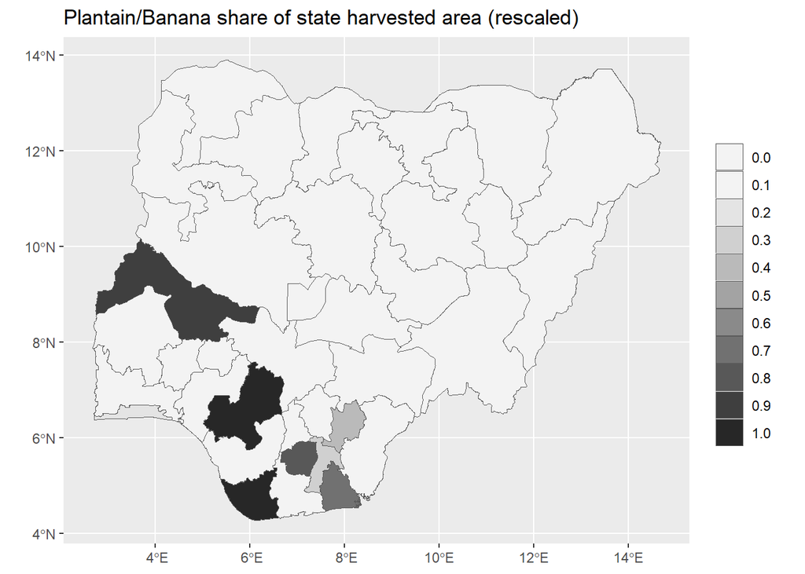

```r
ggplot(vect_state_geo_crop_share_rescale) +
  geom_spatvector(aes(fill = plantain_banana_share_2024)) +
  scale_fill_stepsn(
    n.breaks = 10,
    limits = c(0, 1),
    colours = hcl.colors(palette = "Grays", 10, rev = T),
    guide = "legend",
    na.value = "pink",
    labels = scales::comma
  ) +
  labs(title = "Plantain/Banana share of state harvested area (rescaled)", fill = "") +
  theme(
    plot.title = element_markdown(),
    legend.title = element_markdown(),
    axis.title = element_blank()
  )
```

#### Cassava share of area harvested

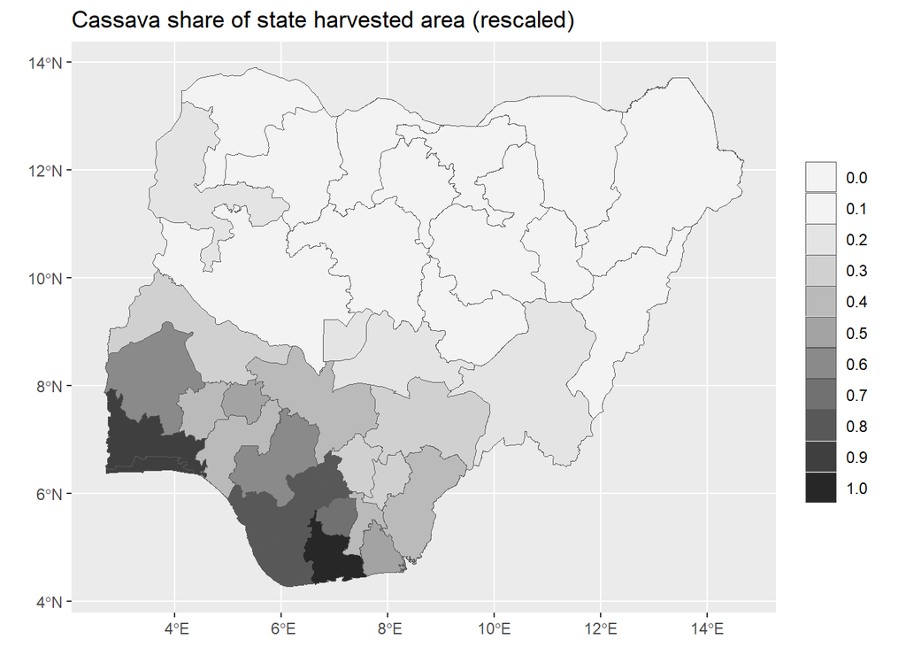

```r
ggplot(vect_state_geo_crop_share_rescale) +
  geom_spatvector(aes(fill = cassava_share_2022)) +
  scale_fill_stepsn(
    n.breaks = 10,
    limits = c(0, 1),
    colours = hcl.colors(palette = "Grays", 10, rev = T),
    guide = "legend",
    na.value = "pink",
    labels = scales::comma
  ) +
  labs(title = "Cassava share of state harvested area (rescaled)", fill = "") +
  theme(
    plot.title = element_markdown(),
    legend.title = element_markdown(),
    axis.title = element_blank()
  )
```

#### Cowpea share of area harvested

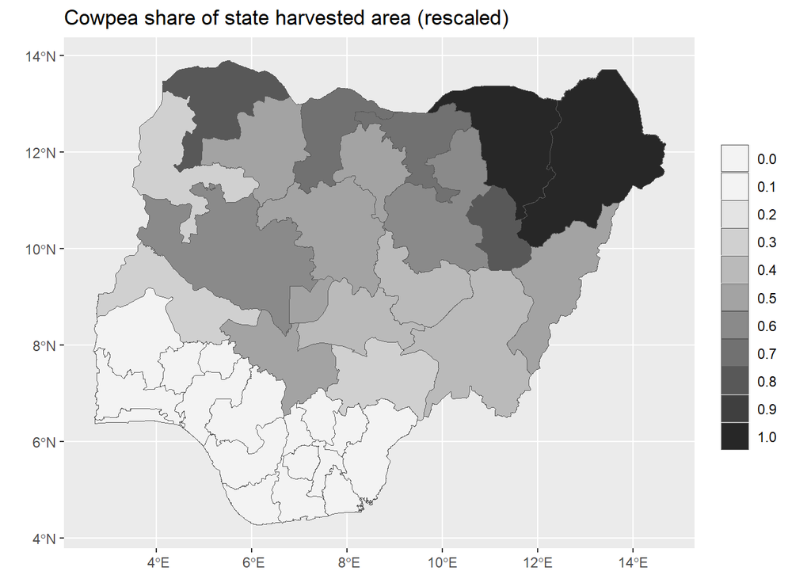

```r
ggplot(vect_state_geo_crop_share_rescale) +
  geom_spatvector(aes(fill = cowpea_share_2022)) +
  scale_fill_stepsn(
    n.breaks = 10,
    limits = c(0, 1),
    colours = hcl.colors(palette = "Grays", 10, rev = T),
    guide = "legend",
    na.value = "pink",
    labels = scales::comma
  ) +
  labs(title = "Cowpea share of state harvested area (rescaled)", fill = "") +
  theme(
    plot.title = element_markdown(),
    legend.title = element_markdown(),
    axis.title = element_blank()
  )
```

#### Maize share of area harvested

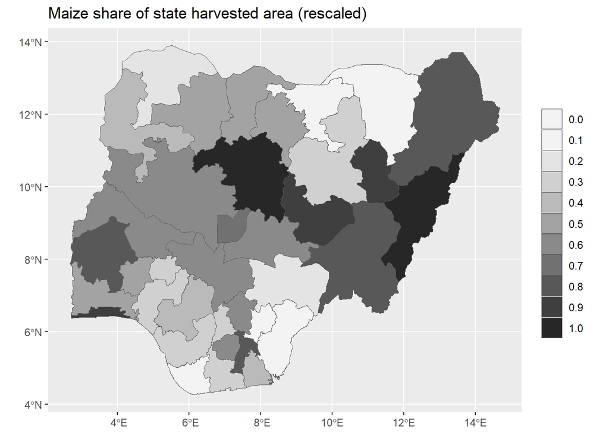

```r
ggplot(vect_state_geo_crop_share_rescale) +
  geom_spatvector(aes(fill = maize_share_2022)) +
  scale_fill_stepsn(
    n.breaks = 10,
    limits = c(0, 1),
    colours = hcl.colors(palette = "Grays", 10, rev = T),
    guide = "legend",
    na.value = "pink",
    labels = scales::comma
  ) +
  labs(title = "Maize share of state harvested area (rescaled)", fill = "") +
  theme(
    plot.title = element_markdown(),
    legend.title = element_markdown(),
    axis.title = element_blank()
  )
```

#### Rice share of area harvested

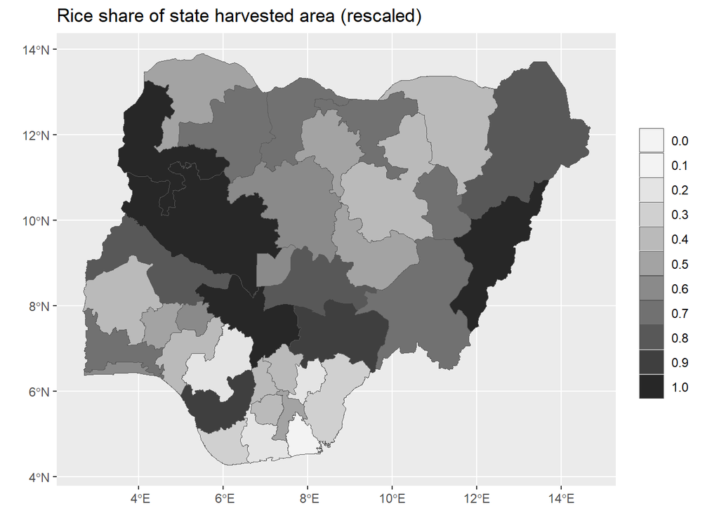

```r
ggplot(vect_state_geo_crop_share_rescale) +
  geom_spatvector(aes(fill = rice_share_2024)) +
  scale_fill_stepsn(
    n.breaks = 10,
    limits = c(0, 1),
    colours = hcl.colors(palette = "Grays", 10, rev = T),
    guide = "legend",
    na.value = "pink",
    labels = scales::comma
  ) +
  labs(title = "Rice share of state harvested area (rescaled)", fill = "") +
  theme(
    plot.title = element_markdown(),
    legend.title = element_markdown(),
    axis.title = element_blank()
  )
```

#### Sorghum share of area harvested

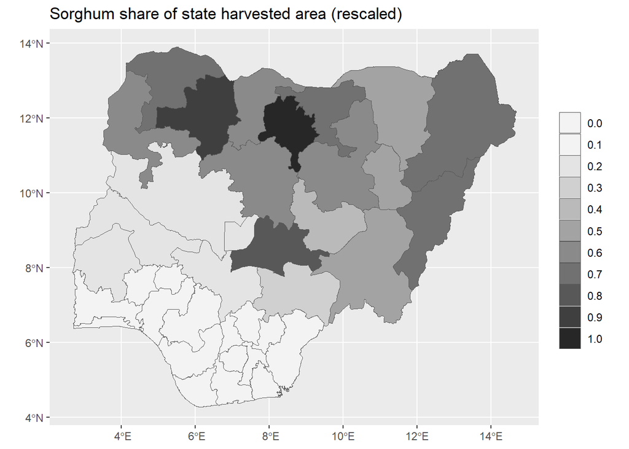

```r
ggplot(vect_state_geo_crop_share_rescale) +
  geom_spatvector(aes(fill = sorghum_share_2024)) +
  scale_fill_stepsn(
    n.breaks = 10,
    limits = c(0, 1),
    colours = hcl.colors(palette = "Grays", 10, rev = T),
    guide = "legend",
    na.value = "pink",
    labels = scales::comma
  ) +
  labs(title = "Sorghum share of state harvested area (rescaled)", fill = "") +
  theme(
    plot.title = element_markdown(),
    legend.title = element_markdown(),
    axis.title = element_blank()
  )
```

#### Sweet Potato share of area harvested

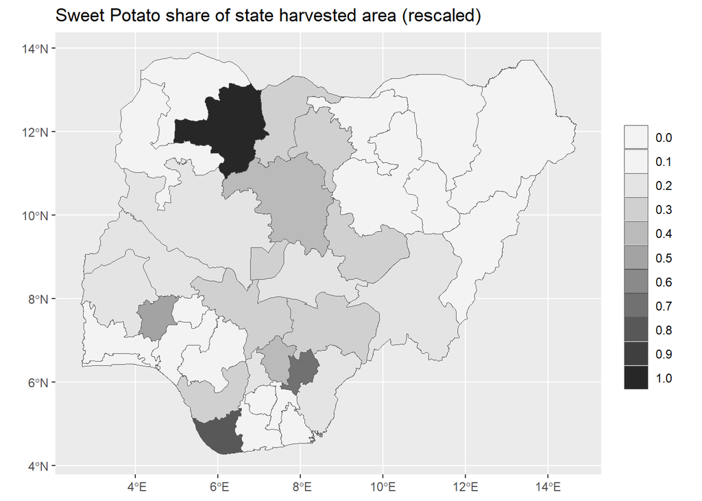

```r
ggplot(vect_state_geo_crop_share_rescale) +
  geom_spatvector(aes(fill = spot_share_2022)) +
  scale_fill_stepsn(
    n.breaks = 10,
    limits = c(0, 1),
    colours = hcl.colors(palette = "Grays", 10, rev = T),
    guide = "legend",
    na.value = "pink",
    labels = scales::comma
  ) +
  labs(title = "Sweet Potato share of state harvested area (rescaled)", fill = "") +
  theme(
    plot.title = element_markdown(),
    legend.title = element_markdown(),
    axis.title = element_blank()
  )
```

### Per-capita area harvested

```r
vect_crop_area_pc <- vect("E:/repos/Nigeria_Biofortification_Atlas/spatial_data/vect_crop_area_pc.geojson")

df_crop_area_pc <- select(as.data.frame(vect_crop_area_pc), adm1_ref_name, plantain_banana_pc_2024, cassava_pc_2022, cowpea_pc_2022, maize_pc_2022, rice_pc_2024, sorghum_pc_2024, spot_pc_2022)

# convert NA values to 0 so that states with no data (which are equivalent to 0 are actually given this value)
df_crop_area_pc[is.na(df_crop_area_pc)] <- 0

df_crop_area_pc_normalised <- as.data.frame(lapply(select(df_crop_area_pc, -adm1_ref_name), minMax))
head(df_crop_area_pc_normalised)
```

```
  plantain_banana_pc_2024 cassava_pc_2022 cowpea_pc_2022 maize_pc_2022
1               0.1258029      0.08115678      0.0000000   0.036889884
2               0.0000000      0.06323808      0.4130704   0.698341806
3               0.2278028      0.06401222      0.0000000   0.011219848
4               0.0000000      0.14964887      0.0000000   0.010592414
5               0.0000000      0.12078693      0.6025029   0.325023489
6               0.9001376      0.18284764      0.0000000   0.002313115
  rice_pc_2024 sorghum_pc_2024 spot_pc_2022
1   0.18920668       0.0000000  0.000000000
2   0.54757520       0.3687122  0.000000000
3   0.00000000       0.0000000  0.005782256
4   0.08201646       0.0000000  0.024322289
5   0.22507755       0.3798893  0.122896736
6   0.25588096       0.0000000  0.150153268
```

```r
df_crop_area_pc_rescale <- bind_cols(select(df_crop_area_pc, adm1_ref_name), df_crop_area_pc_normalised)

vect_state_geo_crop_pc_rescale <- dplyr::left_join(vect_state_geo, df_crop_area_pc_rescale, by = "adm1_ref_name")
```

#### Plantain/Banana per capita area harvested

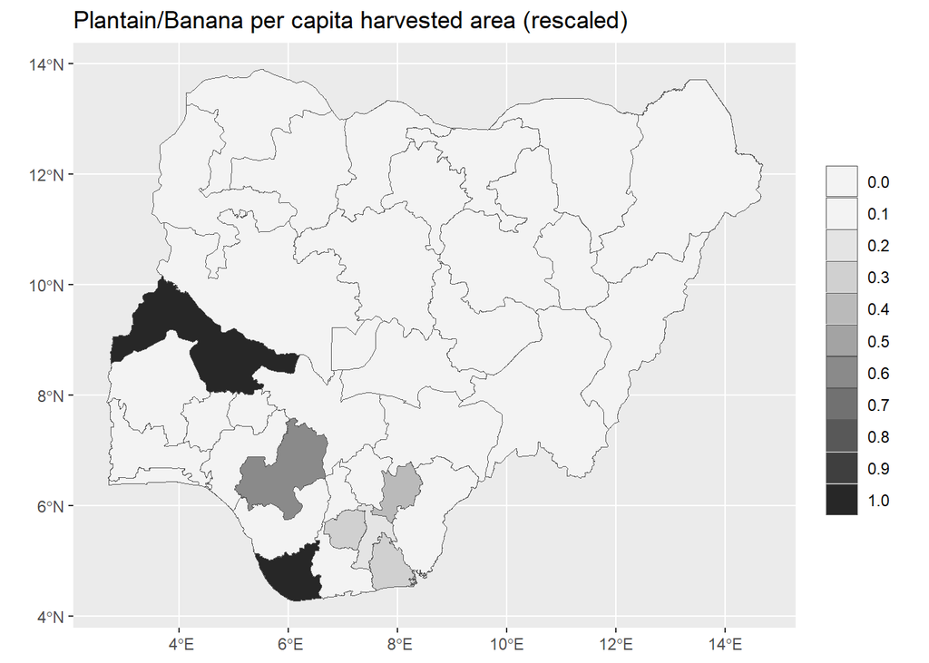

```r
ggplot(vect_state_geo_crop_pc_rescale) +
  geom_spatvector(aes(fill = plantain_banana_pc_2024)) +
  scale_fill_stepsn(
    n.breaks = 10,
    limits = c(0, 1),
    colours = hcl.colors(palette = "Grays", 10, rev = T),
    guide = "legend",
    na.value = "pink",
    labels = scales::comma
  ) +
  labs(title = "Plantain/Banana per capita harvested area (rescaled)", fill = "") +
  theme(
    plot.title = element_markdown(),
    legend.title = element_markdown(),
    axis.title = element_blank()
  )
```

#### Cassava per capita area harvested

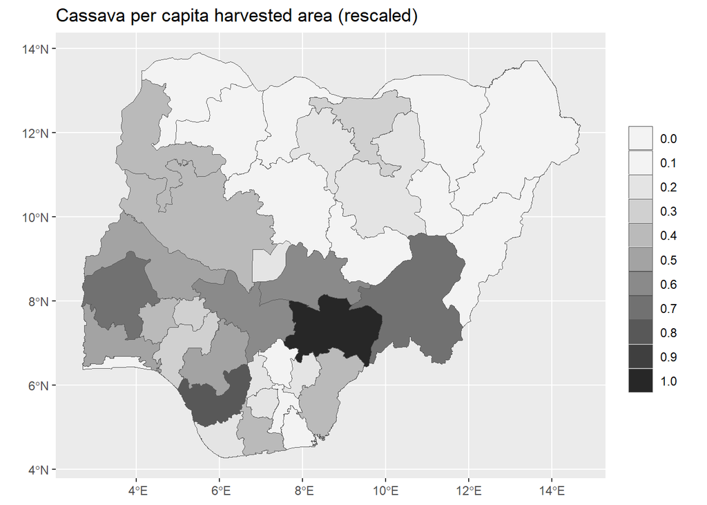

```r
ggplot(vect_state_geo_crop_pc_rescale) +
  geom_spatvector(aes(fill = cassava_pc_2022)) +
  scale_fill_stepsn(
    n.breaks = 10,
    limits = c(0, 1),
    colours = hcl.colors(palette = "Grays", 10, rev = T),
    guide = "legend",
    na.value = "pink",
    labels = scales::comma
  ) +
  labs(title = "Cassava per capita harvested area (rescaled)", fill = "") +
  theme(
    plot.title = element_markdown(),
    legend.title = element_markdown(),
    axis.title = element_blank()
  )
```

#### Cowpea per capita area harvested

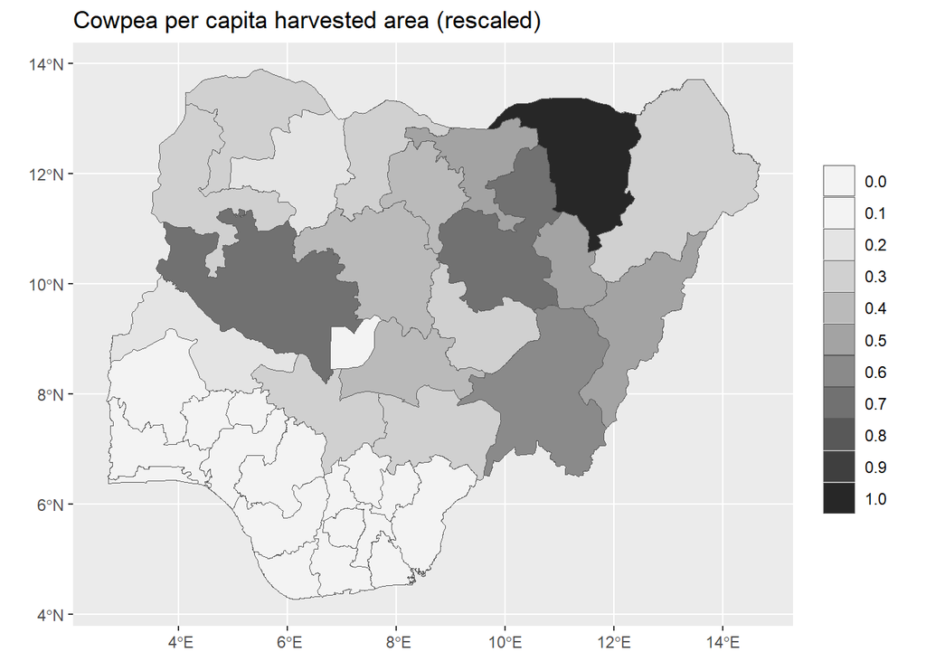

```r
ggplot(vect_state_geo_crop_pc_rescale) +
  geom_spatvector(aes(fill = cowpea_pc_2022)) +
  scale_fill_stepsn(
    n.breaks = 10,
    limits = c(0, 1),
    colours = hcl.colors(palette = "Grays", 10, rev = T),
    guide = "legend",
    na.value = "pink",
    labels = scales::comma
  ) +
  labs(title = "Cowpea per capita harvested area (rescaled)", fill = "") +
  theme(
    plot.title = element_markdown(),
    legend.title = element_markdown(),
    axis.title = element_blank()
  )
```

#### Maize per capita area harvested

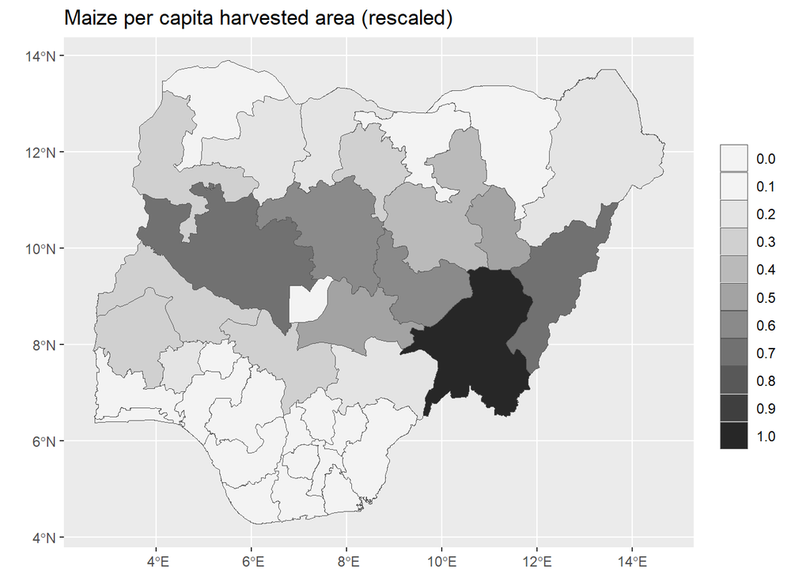

```r
ggplot(vect_state_geo_crop_pc_rescale) +
  geom_spatvector(aes(fill = maize_pc_2022)) +
  scale_fill_stepsn(
    n.breaks = 10,
    limits = c(0, 1),
    colours = hcl.colors(palette = "Grays", 10, rev = T),
    guide = "legend",
    na.value = "pink",
    labels = scales::comma
  ) +
  labs(title = "Maize per capita harvested area (rescaled)", fill = "") +
  theme(
    plot.title = element_markdown(),
    legend.title = element_markdown(),
    axis.title = element_blank()
  )
```

#### Rice per capita area harvested

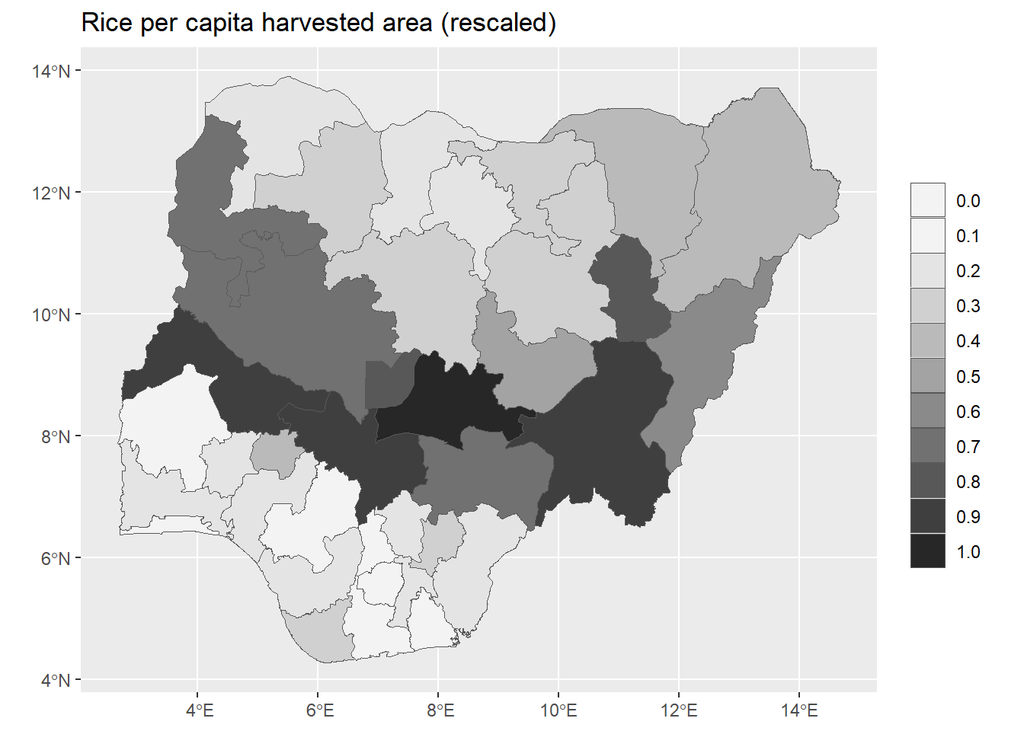

```r
ggplot(vect_state_geo_crop_pc_rescale) +
  geom_spatvector(aes(fill = rice_pc_2024)) +
  scale_fill_stepsn(
    n.breaks = 10,
    limits = c(0, 1),
    colours = hcl.colors(palette = "Grays", 10, rev = T),
    guide = "legend",
    na.value = "pink",
    labels = scales::comma
  ) +
  labs(title = "Rice per capita harvested area (rescaled)", fill = "") +
  theme(
    plot.title = element_markdown(),
    legend.title = element_markdown(),
    axis.title = element_blank()
  )
```

#### Sorghum per capita area harvested

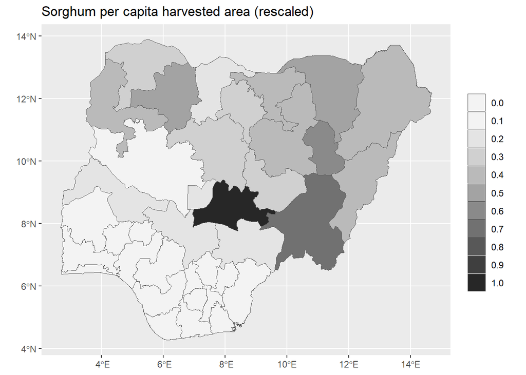

```r
ggplot(vect_state_geo_crop_pc_rescale) +
  geom_spatvector(aes(fill = sorghum_pc_2024)) +
  scale_fill_stepsn(
    n.breaks = 10,
    limits = c(0, 1),
    colours = hcl.colors(palette = "Grays", 10, rev = T),
    guide = "legend",
    na.value = "pink",
    labels = scales::comma
  ) +
  labs(title = "Sorghum per capita harvested area (rescaled)", fill = "") +
  theme(
    plot.title = element_markdown(),
    legend.title = element_markdown(),
    axis.title = element_blank()
  )
```

#### Sweet Potato per capita area harvested

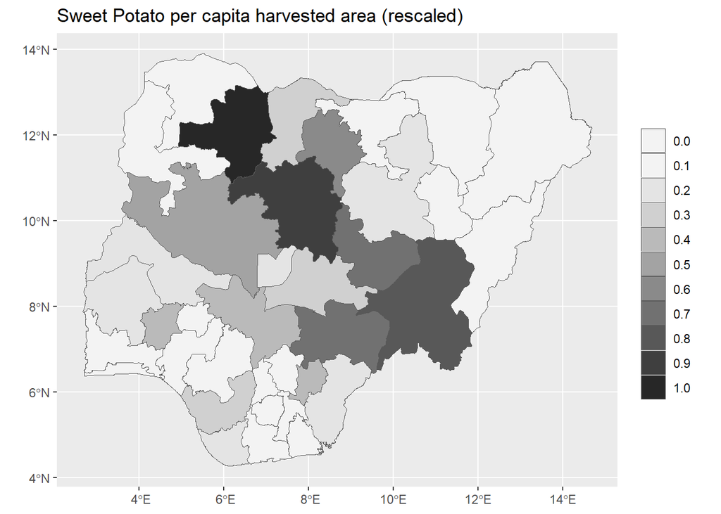

```r
ggplot(vect_state_geo_crop_pc_rescale) +
  geom_spatvector(aes(fill = spot_pc_2022)) +
  scale_fill_stepsn(
    n.breaks = 10,
    limits = c(0, 1),
    colours = hcl.colors(palette = "Grays", 10, rev = T),
    guide = "legend",
    na.value = "pink",
    labels = scales::comma
  ) +
  labs(title = "Sweet Potato per capita harvested area (rescaled)", fill = "") +
  theme(
    plot.title = element_markdown(),
    legend.title = element_markdown(),
    axis.title = element_blank()
  )
```

## Rescale spatially smoothed benchmarked state-level crop consumption estimates

```r
df_GHS_pop_crop_state <- read.csv("tab_data/GHS food per capita outputs/crop_state_results_benchmarked_smoothed.csv")


df_GHS_pop_crop_state_wide <- df_GHS_pop_crop_state |>
  select(state, crop, benchmarked_crop_equivalent_kg_person_year_state) |>
  pivot_wider(names_from = crop, values_from = benchmarked_crop_equivalent_kg_person_year_state)

df_normalised <- as.data.frame(lapply(select(df_GHS_pop_crop_state_wide, -state), minMax))
#head(df_normalised)

df_GHS_pop_crop_state_rescale <- bind_cols(select(df_GHS_pop_crop_state_wide, state), df_normalised)

# convert NA values to 0 so that states with no data (which are equivalent to 0 are actually given this value)
df_GHS_pop_crop_state_rescale[is.na(df_GHS_pop_crop_state_rescale)] <- 0

# get median values of the consumption indices
median_plantain_banana_CI <- median(df_GHS_pop_crop_state_rescale$Plantain)
cat(paste("Median Plantain/Banana CI = ", median_plantain_banana_CI))
```

Median Plantain/Banana CI = 0.0553820552980308

```r
median_cassava_CI <- median(df_GHS_pop_crop_state_rescale$Cassava)
cat(paste("Median Cassava CI = ", median_cassava_CI))
```

Median Cassava CI = 0.295149888308274

```r
median_cocoyam_CI <- median(df_GHS_pop_crop_state_rescale$Cocoyam)
cat(paste("Median Cocoyam CI = ", median_cocoyam_CI))
```

Median Cocoyam CI = 0.0776341900618528

```r
median_cowpea_CI <- median(df_GHS_pop_crop_state_rescale$Cowpea)
cat(paste("Median Cowpea CI = ", median_cowpea_CI))
```

Median Cowpea CI = 0.324543490526814

```r
median_groundnut_CI <- median(df_GHS_pop_crop_state_rescale$Groundnut)
cat(paste("Median Groundnut CI = ", median_groundnut_CI))
```

Median Groundnut CI = 0.0996595409884985

```r
median_maize_CI <- median(df_GHS_pop_crop_state_rescale$Maize)
cat(paste("Median Maize CI = ", median_maize_CI))
```

Median Maize CI = 0.254850542892133

```r
median_millet_CI <- median(df_GHS_pop_crop_state_rescale$Millet)
cat(paste("Median Millet CI = ", median_millet_CI))
```

Median Millet CI = 0.0213190701054455

```r
median_potato_CI <- median(df_GHS_pop_crop_state_rescale$Potato)
cat(paste("Median Potato CI = ", median_potato_CI))
```

Median Potato CI = 0.00303002818789937

```r
median_rice_CI <- median(df_GHS_pop_crop_state_rescale$Rice)
cat(paste("Median Rice CI = ", median_rice_CI))
```

Median Rice CI = 0.433620077876212

```r
median_sorghum_CI <- median(df_GHS_pop_crop_state_rescale$Sorghum)
cat(paste("Median Sorghum CI = ", median_sorghum_CI))
```

Median Sorghum CI = 0.0917625338439095

```r
median_spot_CI <- median(df_GHS_pop_crop_state_rescale$Sweet.potato)
cat(paste("Median Sweet Potato CI = ", median_spot_CI))
```

Median Sweet Potato CI = 0.387928063675711

```r
median_wheat_CI <- median(df_GHS_pop_crop_state_rescale$Wheat)
cat(paste("Median Wheat CI = ", median_wheat_CI))
```

Median Wheat CI = 0.062149447773141

```r
median_yam_CI <- median(df_GHS_pop_crop_state_rescale$Yam)
cat(paste("Median Yam CI = ", median_yam_CI))
```

Median Yam CI = 0.212596682224985

### Join back to States dataset

```r
vect_state_geo_GHS_crop_rescale <- dplyr::left_join(vect_state_geo, df_GHS_pop_crop_state_rescale, by = c("adm1_ref_name" = "state"))
```

### Cassava consumption

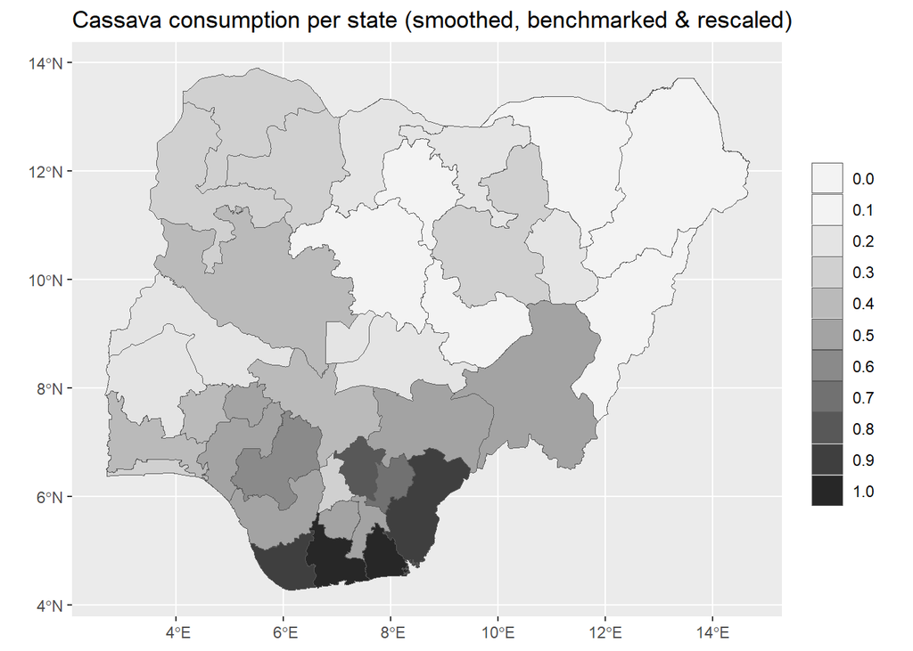

```r
ggplot(vect_state_geo_GHS_crop_rescale) +
  geom_spatvector(aes(fill = Cassava)) +
  scale_fill_stepsn(
    n.breaks = 10,
    limits = c(0, 1),
    colours = hcl.colors(palette = "Grays", 10, rev = T),
    guide = "legend",
    na.value = "pink",
    labels = scales::comma
  ) +
  labs(title = "Cassava consumption per state (smoothed, benchmarked & rescaled)", fill = "") +
  theme(
    plot.title = element_markdown(),
    legend.title = element_markdown(),
    axis.title = element_blank()
  )
```

### Cocoyam consumption

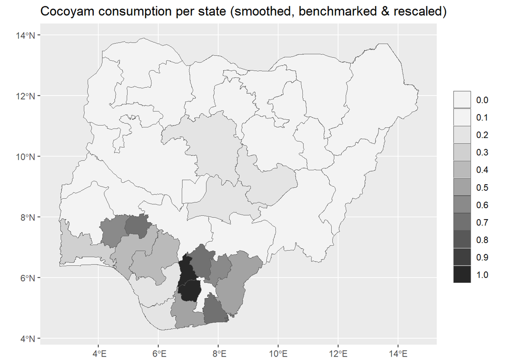

```r
ggplot(vect_state_geo_GHS_crop_rescale) +
  geom_spatvector(aes(fill = Cocoyam)) +
  scale_fill_stepsn(
    n.breaks = 10,
    limits = c(0, 1),
    colours = hcl.colors(palette = "Grays", 10, rev = T),
    guide = "legend",
    na.value = "pink",
    labels = scales::comma
  ) +
  labs(title = "Cocoyam consumption per state (smoothed, benchmarked & rescaled)", fill = "") +
  theme(
    plot.title = element_markdown(),
    legend.title = element_markdown(),
    axis.title = element_blank()
  )
```

### Cowpea consumption

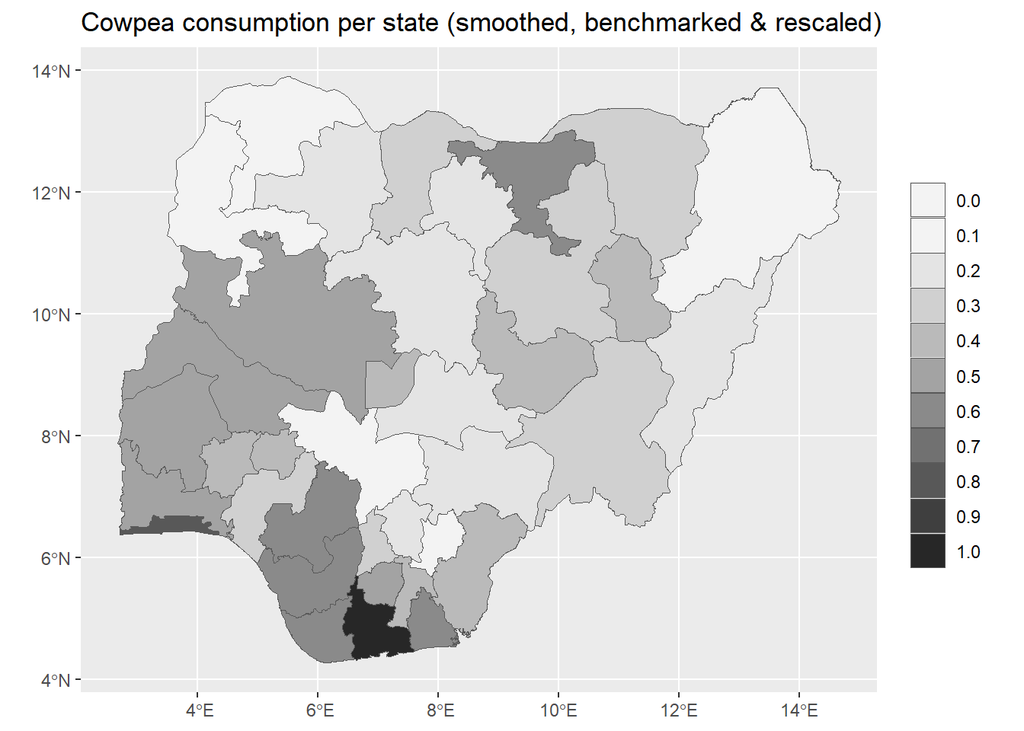

```r
ggplot(vect_state_geo_GHS_crop_rescale) +
  geom_spatvector(aes(fill = Cowpea)) +
  scale_fill_stepsn(
    n.breaks = 10,
    limits = c(0, 1),
    colours = hcl.colors(palette = "Grays", 10, rev = T),
    guide = "legend",
    na.value = "pink",
    labels = scales::comma
  ) +
  labs(title = "Cowpea consumption per state (smoothed, benchmarked & rescaled)", fill = "") +
  theme(
    plot.title = element_markdown(),
    legend.title = element_markdown(),
    axis.title = element_blank()
  )
```

### Maize consumption

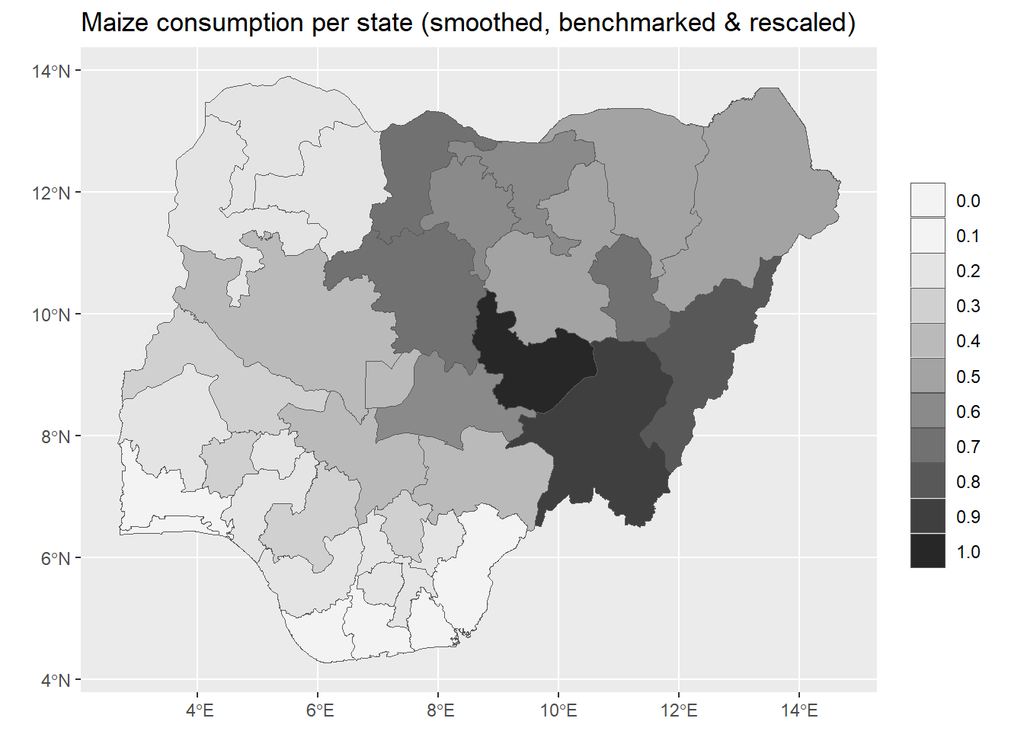

```r
ggplot(vect_state_geo_GHS_crop_rescale) +
  geom_spatvector(aes(fill = Maize)) +
  scale_fill_stepsn(
    n.breaks = 10,
    limits = c(0, 1),
    colours = hcl.colors(palette = "Grays", 10, rev = T),
    guide = "legend",
    na.value = "pink",
    labels = scales::comma
  ) +
  labs(title = "Maize consumption per state (smoothed, benchmarked & rescaled)", fill = "") +
  theme(
    plot.title = element_markdown(),
    legend.title = element_markdown(),
    axis.title = element_blank()
  )
```

### Millet consumption

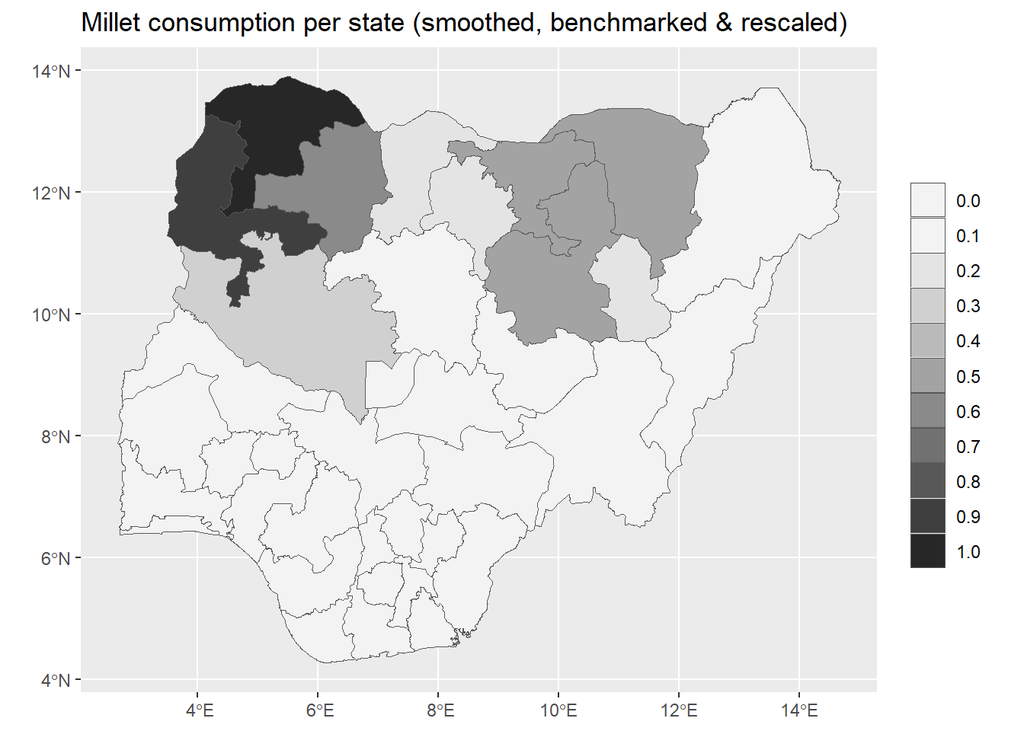

```r
ggplot(vect_state_geo_GHS_crop_rescale) +
  geom_spatvector(aes(fill = Millet)) +
  scale_fill_stepsn(
    n.breaks = 10,
    limits = c(0, 1),
    colours = hcl.colors(palette = "Grays", 10, rev = T),
    guide = "legend",
    na.value = "pink",
    labels = scales::comma
  ) +
  labs(title = "Millet consumption per state (smoothed, benchmarked & rescaled)", fill = "") +
  theme(
    plot.title = element_markdown(),
    legend.title = element_markdown(),
    axis.title = element_blank()
  )
```

### Potato consumption

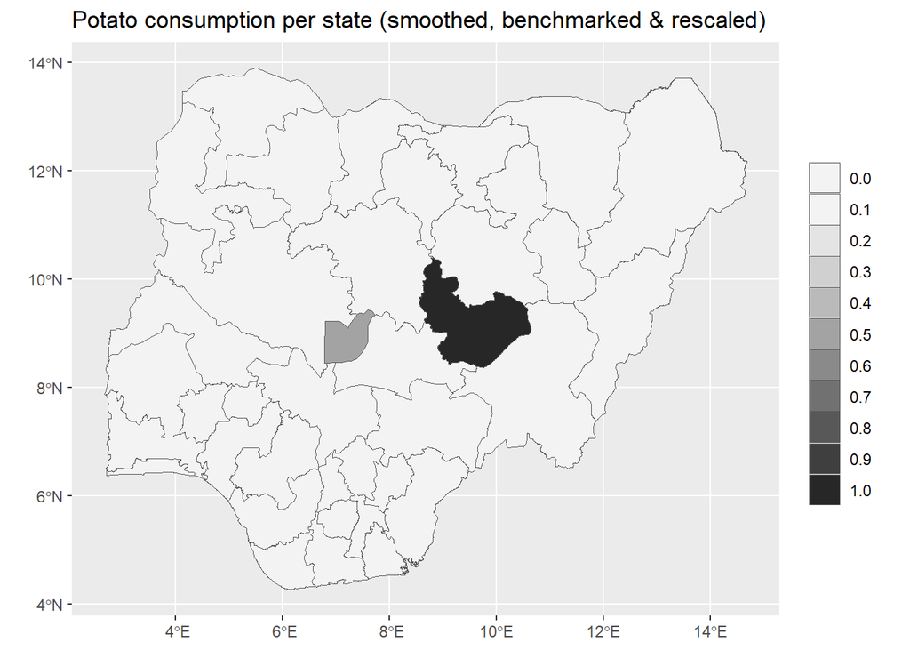

```r
ggplot(vect_state_geo_GHS_crop_rescale) +
  geom_spatvector(aes(fill = Potato)) +
  scale_fill_stepsn(
    n.breaks = 10,
    limits = c(0, 1),
    colours = hcl.colors(palette = "Grays", 10, rev = T),
    guide = "legend",
    na.value = "pink",
    labels = scales::comma
  ) +
  labs(title = "Potato consumption per state (smoothed, benchmarked & rescaled)", fill = "") +
  theme(
    plot.title = element_markdown(),
    legend.title = element_markdown(),
    axis.title = element_blank()
  )
```

### Plantain consumption

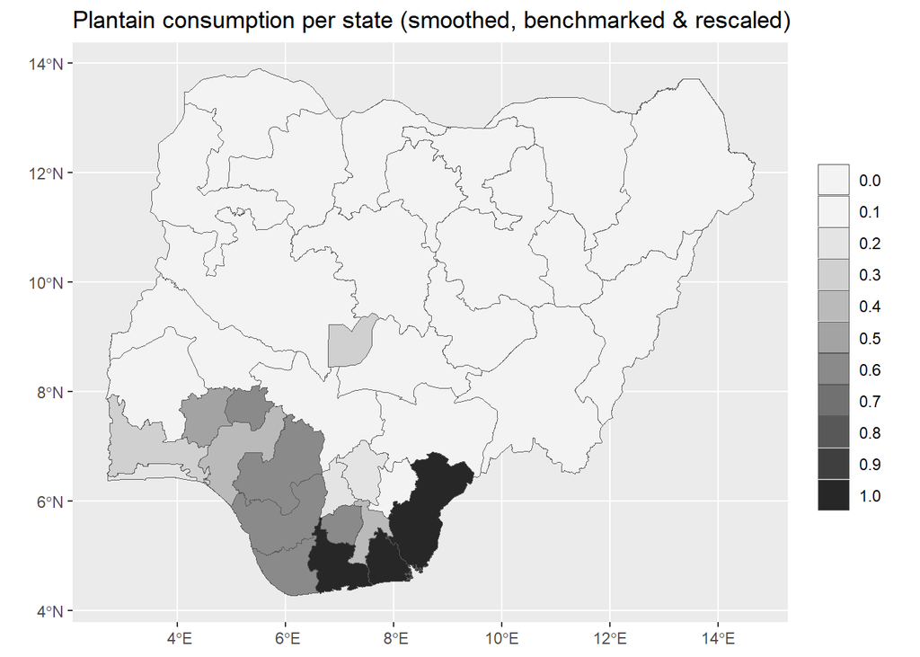

```r
ggplot(vect_state_geo_GHS_crop_rescale) +
  geom_spatvector(aes(fill = Plantain)) +
  scale_fill_stepsn(
    n.breaks = 10,
    limits = c(0, 1),
    colours = hcl.colors(palette = "Grays", 10, rev = T),
    guide = "legend",
    na.value = "pink",
    labels = scales::comma
  ) +
  labs(title = "Plantain consumption per state (smoothed, benchmarked & rescaled)", fill = "") +
  theme(
    plot.title = element_markdown(),
    legend.title = element_markdown(),
    axis.title = element_blank()
  )
```

### Rice consumption

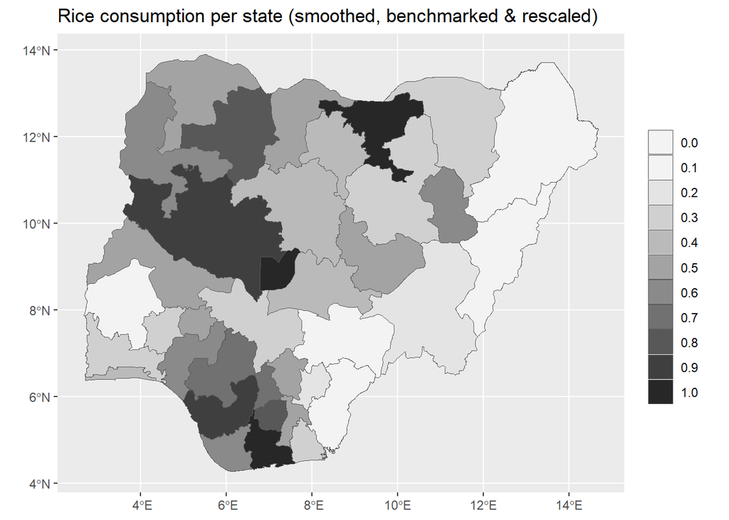

```r
ggplot(vect_state_geo_GHS_crop_rescale) +
  geom_spatvector(aes(fill = Rice)) +
  scale_fill_stepsn(
    n.breaks = 10,
    limits = c(0, 1),
    colours = hcl.colors(palette = "Grays", 10, rev = T),
    guide = "legend",
    na.value = "pink",
    labels = scales::comma
  ) +
  labs(title = "Rice consumption per state (smoothed, benchmarked & rescaled)", fill = "") +
  theme(
    plot.title = element_markdown(),
    legend.title = element_markdown(),
    axis.title = element_blank()
  )
```

### Sorghum consumption

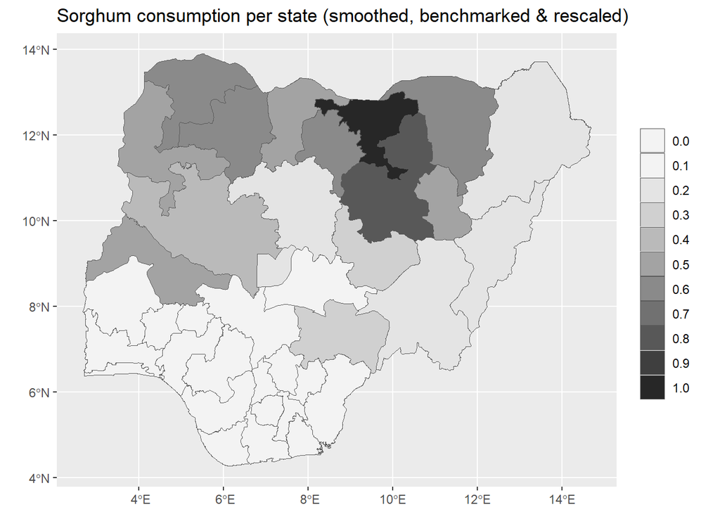

```r
ggplot(vect_state_geo_GHS_crop_rescale) +
  geom_spatvector(aes(fill = Sorghum)) +
  scale_fill_stepsn(
    n.breaks = 10,
    limits = c(0, 1),
    colours = hcl.colors(palette = "Grays", 10, rev = T),
    guide = "legend",
    na.value = "pink",
    labels = scales::comma
  ) +
  labs(title = "Sorghum consumption per state (smoothed, benchmarked & rescaled)", fill = "") +
  theme(
    plot.title = element_markdown(),
    legend.title = element_markdown(),
    axis.title = element_blank()
  )
```

### Sweet potato consumption

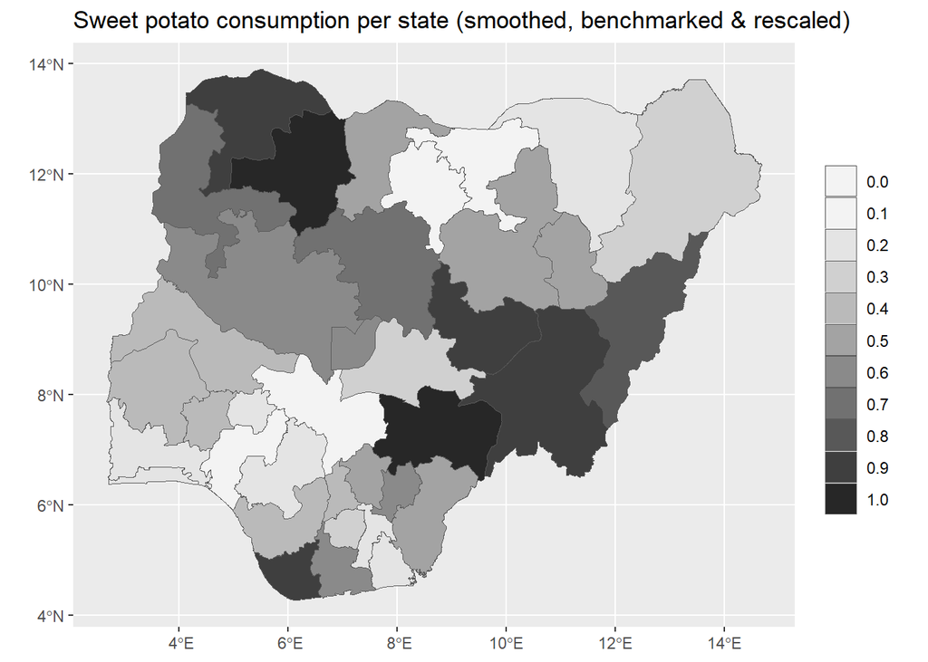

```r
ggplot(vect_state_geo_GHS_crop_rescale) +
  geom_spatvector(aes(fill = Sweet.potato)) +
  scale_fill_stepsn(
    n.breaks = 10,
    limits = c(0, 1),
    colours = hcl.colors(palette = "Grays", 10, rev = T),
    guide = "legend",
    na.value = "pink",
    labels = scales::comma
  ) +
  labs(title = "Sweet potato consumption per state (smoothed, benchmarked & rescaled)", fill = "") +
  theme(
    plot.title = element_markdown(),
    legend.title = element_markdown(),
    axis.title = element_blank()
  )
```

### Wheat consumption

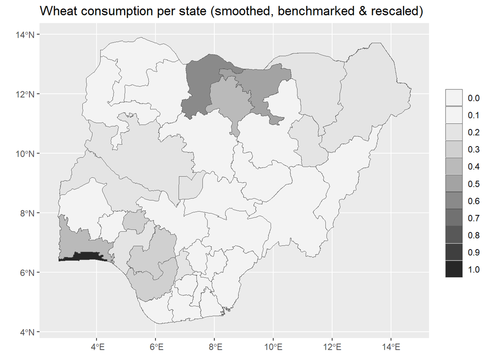

```r
ggplot(vect_state_geo_GHS_crop_rescale) +
  geom_spatvector(aes(fill = Wheat)) +
  scale_fill_stepsn(
    n.breaks = 10,
    limits = c(0, 1),
    colours = hcl.colors(palette = "Grays", 10, rev = T),
    guide = "legend",
    na.value = "pink",
    labels = scales::comma
  ) +
  labs(title = "Wheat consumption per state (smoothed, benchmarked & rescaled)", fill = "") +
  theme(
    plot.title = element_markdown(),
    legend.title = element_markdown(),
    axis.title = element_blank()
  )
```

### Yam consumption

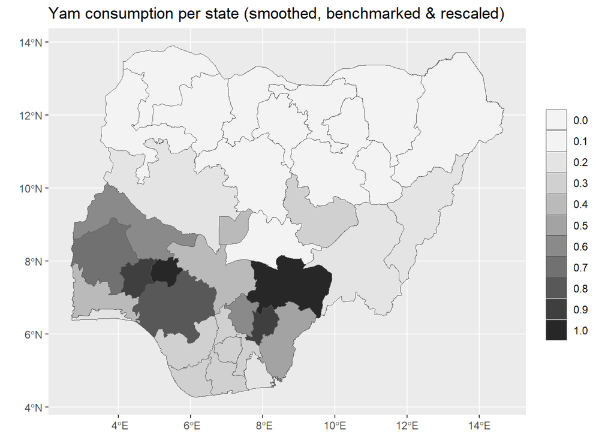

```r
ggplot(vect_state_geo_GHS_crop_rescale) +
  geom_spatvector(aes(fill = Yam)) +
  scale_fill_stepsn(
    n.breaks = 10,
    limits = c(0, 1),
    colours = hcl.colors(palette = "Grays", 10, rev = T),
    guide = "legend",
    na.value = "pink",
    labels = scales::comma
  ) +
  labs(title = "Yam consumption per state (smoothed, benchmarked & rescaled)", fill = "") +
  theme(
    plot.title = element_markdown(),
    legend.title = element_markdown(),
    axis.title = element_blank()
  )
```

## Micronutrient Deficiency Index

### Load the NFCMS 2021 databases

The NFCMS data are loaded and there are data available for the following zones:

```r
df_NFCMS <- read.csv("E:/repos/Nigeria_Biofortification_Atlas/tab_data/NFCMS_deficiencies.csv")

df_NFCMS$geopolitical_zone <- as.factor(df_NFCMS$geopolitical_zone)

cat(paste(levels(df_NFCMS$geopolitical_zone), "; ")) # Check levels
```

North Central ; North East ; North West ; South East ; South South ; South West ;

```r
df_NFCMS_consumption <- read.csv("E:/repos/Biofort_Atlas_Nigeria/tab_data/NFCMS_consumption.csv")

df_NFCMS_consumption$geopolitical_zone <- as.factor(df_NFCMS_consumption$geopolitical_zone)

cat(paste(levels(df_NFCMS_consumption$geopolitical_zone), "; ")) # Check levels
```

North Central ; North East ; North West ; South East ; South South ; South West ;

### Join the NFCMS database to the zone dataset

The NFCMS dataset does not contain codes for the zones - only names. Therefore we need to join the two data frames using the name of the zone - and checking that all zones have data.

```r
vect_gpz_geo_NFCMS <- dplyr::left_join(vect_gpz_geo, df_NFCMS, by = c("geopolitical_zone"))
vect_gpz_geo_NFCMS |> as.data.frame() |>
  DT::datatable(
    rownames = F,
    filter = "bottom",
    selection = list(mode = "none"),
    editable = FALSE,
    options = list(
      digits = 0,
      scrollX = TRUE,
      scrollCollapse = TRUE,
      autoWidth = TRUE,
      fixedColumns = list(leftColumns = 2),
      lengthMenu = c(15, 40),
      pageLength = 15
    ))
```

| geopolitical_zone | mean_area_sqkm | mean_center_lat | mean_center_lon | id | valid_on | valid_to | adm0_pcode | adm0_name3 | adm1_ref_name | adm0_name2 | adm0_name | adm1_pcode | adm0_name1 | lang1 | lang3 | adm1_name3 | adm1_name2 | version | lang | adm1_name1 | adm1_name | lang2 | agg_n | CH_def_iron_pc_235 | CH_def_anaemia_pc_235 | CH_def_vit_A_pc_236 | CH_def_vit_B12_pc_237 | CH_def_zinc_pc_238 | WRA_def_iron_pc_245 | … |
| --- | --- | --- | --- | --- | --- | --- | --- | --- | --- | --- | --- | --- | --- | --- | --- | --- | --- | --- | --- | --- | --- | --- | --- | --- | --- | --- | --- | --- | --- | --- |
| North Central | 32374.02856471428 | 8.683830957142858 | 7.281445614285714 |  | 2019-04-17T05:00:00Z |  | NG |  |  |  | Nigeria |  |  |  |  |  |  | v01 | en |  |  |  | 7 | 20.7 | 8 | 15.5 | 1.1 | 23.4 | 9.1 | … |
| North East | 46551.80045726667 | 10.41556971666667 | 11.36336905 |  | 2019-04-17T05:00:00Z |  | NG |  |  |  | Nigeria |  |  |  |  |  |  | v01 | en |  |  |  | 6 | 27.9 | 7.5 | 31.7 | 4.1 | 31.2 | 15.5 | … |
| North West | 30559.98868224286 | 11.78441014285714 | 6.968847014285714 |  | 2019-04-17T05:00:00Z |  | NG |  |  |  | Nigeria |  |  |  |  |  |  | v01 | en |  |  |  | 7 | 25.5 | 13 | 50.6 | 4.5 | 56.5 | 9.1 | … |
| South East | 5742.88735864 | 6.00114194 | 7.38378392 |  | 2019-04-17T05:00:00Z |  | NG |  |  |  | Nigeria |  |  |  |  |  |  | v01 | en |  |  |  | 5 | 11.5 | 3.8 | 6.1 | 1.1 | 11.8 | 10.4 | … |
| South South | 13999.63981785 | 5.508994833333333 | 6.726541516666667 |  | 2019-04-17T05:00:00Z |  | NG |  |  |  | Nigeria |  |  |  |  |  |  | v01 | en |  |  |  | 6 | 9.4 | 4 | 18.8 | 0.2 | 22.4 | 12.2 | … |
| South West | 12895.26095053333 | 7.309125083333333 | 4.21263045 |  | 2019-04-17T05:00:00Z |  | NG |  |  |  | Nigeria |  |  |  |  |  |  | v01 | en |  |  |  | 6 | 10.8 | 4.4 | 18.5 | 0 | 22.7 | 5.2 | … |

### Join the NFCMS database to the zone dataset

The NFCMS dataset does not contain codes for the zones - only names. Therefore we need to join the two data frames using the name of the zone - and checking that all zones have data.

```r
vect_gpz_geo_NFCMS_consumption <- dplyr::left_join(vect_gpz_geo, df_NFCMS_consumption, by = c("geopolitical_zone"))
vect_gpz_geo_NFCMS_consumption |> as.data.frame() |>
  DT::datatable(
    rownames = F,
    caption = "NFCMS Consumption summary",
    filter = "bottom",
    selection = list(mode = "none"),
    editable = FALSE,
    options = list(
      digits = 0,
      scrollX = TRUE,
      scrollCollapse = TRUE,
      autoWidth = TRUE,
      fixedColumns = list(leftColumns = 2),
      lengthMenu = c(15, 40),
      pageLength = 15
    ))
```

| geopolitical_zone | mean_area_sqkm | mean_center_lat | mean_center_lon | id | valid_on | valid_to | adm0_pcode | adm0_name3 | adm1_ref_name | adm0_name2 | adm0_name | adm1_pcode | adm0_name1 | lang1 | lang3 | adm1_name3 | adm1_name2 | version | lang | adm1_name1 | adm1_name | lang2 | agg_n | WRA_cass_vit_A_pc_cons_fig10 | WRA_cass_vit_A_daily_122 | WRA_cass_vit_A_pc_energy_124 | WRA_cass_vit_A_pc_vit_A_126 | WRA_ofsp_pc_cons_fig12 | WRA_ofsp_daily_128 | … |
| --- | --- | --- | --- | --- | --- | --- | --- | --- | --- | --- | --- | --- | --- | --- | --- | --- | --- | --- | --- | --- | --- | --- | --- | --- | --- | --- | --- | --- | --- | --- |
| North Central | 32374.02856471428 | 8.683830957142858 | 7.281445614285714 |  | 2019-04-17T05:00:00Z |  | NG |  |  |  | Nigeria |  |  |  |  |  |  | v01 | en |  |  |  | 7 | 2.7 | 0.4 | 1.24 | 0.2 | 2.2 | 0.14 | … |
| North East | 46551.80045726667 | 10.41556971666667 | 11.36336905 |  | 2019-04-17T05:00:00Z |  | NG |  |  |  | Nigeria |  |  |  |  |  |  | v01 | en |  |  |  | 6 | 8.3 | 0.23 | 0.25 | 0.04 | 16.8 | 0.46 | … |
| North West | 30559.98868224286 | 11.78441014285714 | 6.968847014285714 |  | 2019-04-17T05:00:00Z |  | NG |  |  |  | Nigeria |  |  |  |  |  |  | v01 | en |  |  |  | 7 | 1 | 0.62 | 0.17 | 0.05 | 2.1 | 0.33 | … |
| South East | 5742.88735864 | 6.00114194 | 7.38378392 |  | 2019-04-17T05:00:00Z |  | NG |  |  |  | Nigeria |  |  |  |  |  |  | v01 | en |  |  |  | 5 | 4.1 | 1.36 | 1.82 | 0.13 | 2.1 | 0.22 | … |
| South South | 13999.63981785 | 5.508994833333333 | 6.726541516666667 |  | 2019-04-17T05:00:00Z |  | NG |  |  |  | Nigeria |  |  |  |  |  |  | v01 | en |  |  |  | 6 | 3.5 | 6.33 | 0.56 | 0.05 | 2.5 | 0.37 | … |
| South West | 12895.26095053333 | 7.309125083333333 | 4.21263045 |  | 2019-04-17T05:00:00Z |  | NG |  |  |  | Nigeria |  |  |  |  |  |  | v01 | en |  |  |  | 6 | 1.7 | 0.46 | 1.6 | 0.21 | 2.3 | 0.04 | … |

### Load the Institute for Health Metrics and Evaluation (IHME) Global Burden of Disease (GBD) - 2023 database

The IHME data are loaded and there are data available for the following zones:

```r
df_IHME <- read.csv("E:/repos/Nigeria_Biofortification_Atlas/tab_data/IHME-GBD_2023.csv")

df_IHME$location_name <- as.factor(df_IHME$location_name)

cat(paste(levels(df_IHME$location_name), "; ")) # Check levels
```

Abia ; Adamawa ; Akwa Ibom ; Anambra ; Bauchi ; Bayelsa ; Benue ; Borno ; Cross River ; Delta ; Ebonyi ; Edo ; Ekiti ; Enugu ; Federal Capital Territory ; Gombe ; Imo ; Jigawa ; Kaduna ; Kano ; Katsina ; Kebbi ; Kogi ; Kwara ; Lagos ; Nasarawa ; Niger ; Ogun ; Ondo ; Osun ; Oyo ; Plateau ; Rivers ; Sokoto ; Taraba ; Yobe ; Zamfara ;

### Join the IHME database to the state dataset

The IHME dataset does not contain codes for the states - only names. Therefore we need to join the two data frames using the name of the state - and checking that all states have data.

```r
vect_state_geo_IHME <- dplyr::left_join(vect_state_geo, df_IHME, by = c("adm1_ref_name"  = "location_name"))
vect_state_geo_IHME |> as.data.frame() |>
  DT::datatable(
    rownames = F,
    filter = "bottom",
    selection = list(mode = "none"),
    editable = FALSE,
    options = list(
      digits = 0,
      scrollX = TRUE,
      scrollCollapse = TRUE,
      autoWidth = TRUE,
      fixedColumns = list(leftColumns = 2),
      lengthMenu = c(15, 40),
      pageLength = 15
    ))
```

| id | area_sqkm | valid_on | valid_to | adm0_pcode | adm0_name3 | adm1_ref_name | adm0_name2 | adm0_name | adm1_pcode | adm0_name1 | lang1 | lang3 | adm1_name3 | adm1_name2 | version | lang | adm1_name1 | adm1_name | lang2 | center_lat | center_lon | population_group_id | population_group_name | measure_id | measure_name | location_id | sex_id | sex_name | age_id | … |
| --- | --- | --- | --- | --- | --- | --- | --- | --- | --- | --- | --- | --- | --- | --- | --- | --- | --- | --- | --- | --- | --- | --- | --- | --- | --- | --- | --- | --- | --- | --- |
|  | 4859.5031378 | 2019-04-17T05:00:00Z |  | NG |  | Abia |  | Nigeria | NG001 |  |  |  |  |  | v01 | en |  | Abia |  | 5.4318197 | 7.4883421 | 1 | All Population | 2 | DALYs (Disability-Adjusted Life Years) | 25318 | 3 | Both | 27 | … |
|  | 4859.5031378 | 2019-04-17T05:00:00Z |  | NG |  | Abia |  | Nigeria | NG001 |  |  |  |  |  | v01 | en |  | Abia |  | 5.4318197 | 7.4883421 | 1 | All Population | 2 | DALYs (Disability-Adjusted Life Years) | 25318 | 3 | Both | 27 | … |
|  | 37821.6738411 | 2019-04-17T05:00:00Z |  | NG |  | Adamawa |  | Nigeria | NG002 |  |  |  |  |  | v01 | en |  | Adamawa |  | 9.1626472 | 12.2915621 | 1 | All Population | 2 | DALYs (Disability-Adjusted Life Years) | 25319 | 3 | Both | 27 | … |
|  | 37821.6738411 | 2019-04-17T05:00:00Z |  | NG |  | Adamawa |  | Nigeria | NG002 |  |  |  |  |  | v01 | en |  | Adamawa |  | 9.1626472 | 12.2915621 | 1 | All Population | 2 | DALYs (Disability-Adjusted Life Years) | 25319 | 3 | Both | 27 | … |
|  | 6739.3559919 | 2019-04-17T05:00:00Z |  | NG |  | Akwa Ibom |  | Nigeria | NG003 |  |  |  |  |  | v01 | en |  | Akwa Ibom |  | 4.99047 | 7.7955686 | 1 | All Population | 2 | DALYs (Disability-Adjusted Life Years) | 25320 | 3 | Both | 27 | … |
|  | 6739.3559919 | 2019-04-17T05:00:00Z |  | NG |  | Akwa Ibom |  | Nigeria | NG003 |  |  |  |  |  | v01 | en |  | Akwa Ibom |  | 4.99047 | 7.7955686 | 1 | All Population | 2 | DALYs (Disability-Adjusted Life Years) | 25320 | 3 | Both | 27 | … |
|  | 4805.5194821 | 2019-04-17T05:00:00Z |  | NG |  | Anambra |  | Nigeria | NG004 |  |  |  |  |  | v01 | en |  | Anambra |  | 6.2485292 | 6.9378734 | 1 | All Population | 2 | DALYs (Disability-Adjusted Life Years) | 25321 | 3 | Both | 27 | … |
|  | 4805.5194821 | 2019-04-17T05:00:00Z |  | NG |  | Anambra |  | Nigeria | NG004 |  |  |  |  |  | v01 | en |  | Anambra |  | 6.2485292 | 6.9378734 | 1 | All Population | 2 | DALYs (Disability-Adjusted Life Years) | 25321 | 3 | Both | 27 | … |
|  | 48516.7133317 | 2019-04-17T05:00:00Z |  | NG |  | Bauchi |  | Nigeria | NG005 |  |  |  |  |  | v01 | en |  | Bauchi |  | 10.9978941 | 9.3258168 | 1 | All Population | 2 | DALYs (Disability-Adjusted Life Years) | 25322 | 3 | Both | 27 | … |
|  | 48516.7133317 | 2019-04-17T05:00:00Z |  | NG |  | Bauchi |  | Nigeria | NG005 |  |  |  |  |  | v01 | en |  | Bauchi |  | 10.9978941 | 9.3258168 | 1 | All Population | 2 | DALYs (Disability-Adjusted Life Years) | 25322 | 3 | Both | 27 | … |

[output cut: 64 more lines]

### Load the NDHS database

```r
df_NDHS_state <- read.csv("E:/repos/Nigeria_Biofortification_Atlas/tab_data/NDHS_state_deficiencies.csv")
# change name to match states dataset
df_NDHS_state['State'][df_NDHS_state['State'] == "FCT-Abuja"] <- "Federal Capital Territory"

df_NDHS_state$State <- as.factor(df_NDHS_state$State)

cat(paste(levels(df_NDHS_state$State), "; ")) # Check levels
```

Abia ; Adamawa ; Akwa Ibom ; Anambra ; Bauchi ; Bayelsa ; Benue ; Borno ; Cross River ; Delta ; Ebonyi ; Edo ; Ekiti ; Enugu ; Federal Capital Territory ; Gombe ; Imo ; Jigawa ; Kaduna ; Kano ; Katsina ; Kebbi ; Kogi ; Kwara ; Lagos ; Nasarawa ; Niger ; Ogun ; Ondo ; Osun ; Oyo ; Plateau ; Rivers ; Sokoto ; Taraba ; Yobe ; Zamfara ;

### Join the NDHS database to the state dataset

```r
vect_state_geo_NDHS <- dplyr::left_join(vect_state_geo, df_NDHS_state, by = c("adm1_ref_name"  = "State"))
vect_state_geo_NDHS |> as.data.frame() |>
  DT::datatable(
    rownames = F,
    filter = "bottom",
    selection = list(mode = "none"),
    editable = FALSE,
    options = list(
      digits = 0,
      scrollX = TRUE,
      scrollCollapse = TRUE,
      autoWidth = TRUE,
      fixedColumns = list(leftColumns = 2),
      lengthMenu = c(15, 40),
      pageLength = 15
    ))
```

| id | area_sqkm | valid_on | valid_to | adm0_pcode | adm0_name3 | adm1_ref_name | adm0_name2 | adm0_name | adm1_pcode | adm0_name1 | lang1 | lang3 | adm1_name3 | adm1_name2 | version | lang | adm1_name1 | adm1_name | lang2 | center_lat | center_lon | CH_anaemia_any | CH_anaemia_mild | CH_anaemia_mod | CH_anaemia_sev | WRA_anaemia_any | WRA_anaemia_mild | WRA_anaemia_mod | WRA_anaemia_sev |
| --- | --- | --- | --- | --- | --- | --- | --- | --- | --- | --- | --- | --- | --- | --- | --- | --- | --- | --- | --- | --- | --- | --- | --- | --- | --- | --- | --- | --- | --- |
|  | 4859.5031378 | 2019-04-17T05:00:00Z |  | NG |  | Abia |  | Nigeria | NG001 |  |  |  |  |  | v01 | en |  | Abia |  | 5.4318197 | 7.4883421 | 64.1 | 38.4 | 25.4 | 0.3 | 66.3 | 28.7 | 36.5 | 1.2 |
|  | 37821.6738411 | 2019-04-17T05:00:00Z |  | NG |  | Adamawa |  | Nigeria | NG002 |  |  |  |  |  | v01 | en |  | Adamawa |  | 9.1626472 | 12.2915621 | 59 | 25.1 | 29.3 | 4.6 | 50 | 22.4 | 26.3 | 1.3 |
|  | 6739.3559919 | 2019-04-17T05:00:00Z |  | NG |  | Akwa Ibom |  | Nigeria | NG003 |  |  |  |  |  | v01 | en |  | Akwa Ibom |  | 4.99047 | 7.7955686 | 74.5 | 28.3 | 45.6 | 0.7 | 54.8 | 24.8 | 28.9 | 1.1 |
|  | 4805.5194821 | 2019-04-17T05:00:00Z |  | NG |  | Anambra |  | Nigeria | NG004 |  |  |  |  |  | v01 | en |  | Anambra |  | 6.2485292 | 6.9378734 | 52.9 | 30.3 | 21.9 | 0.6 | 54.9 | 32.5 | 22.4 | 0.1 |
|  | 48516.7133317 | 2019-04-17T05:00:00Z |  | NG |  | Bauchi |  | Nigeria | NG005 |  |  |  |  |  | v01 | en |  | Bauchi |  | 10.9978941 | 9.3258168 | 65.3 | 25.1 | 37.3 | 2.9 | 54.4 | 27.1 | 24 | 3.3 |
|  | 9529.0165288 | 2019-04-17T05:00:00Z |  | NG |  | Bayelsa |  | Nigeria | NG006 |  |  |  |  |  | v01 | en |  | Bayelsa |  | 4.8268244 | 5.951137 | 50.1 | 30.7 | 18.6 | 0.8 | 47.7 | 27.8 | 19.9 | 0 |
|  | 31483.3370793 | 2019-04-17T05:00:00Z |  | NG |  | Benue |  | Nigeria | NG007 |  |  |  |  |  | v01 | en |  | Benue |  | 7.3009378 | 8.8123949 | 51 | 32.1 | 18.4 | 0.6 | 29.4 | 20.2 | 8.8 | 0.4 |
|  | 72156.5967627 | 2019-04-17T05:00:00Z |  | NG |  | Borno |  | Nigeria | NG008 |  |  |  |  |  | v01 | en |  | Borno |  | 11.8700727 | 13.4276227 | 61.4 | 33.7 | 26.9 | 0.8 | 44.8 | 22.4 | 21.2 | 1.3 |
|  | 20954.9259246 | 2019-04-17T05:00:00Z |  | NG |  | Cross River |  | Nigeria | NG009 |  |  |  |  |  | v01 | en |  | Cross River |  | 5.7913258 | 8.4034469 | 52.6 | 37 | 15.6 | 0 | 40.1 | 27.4 | 12.6 | 0 |
|  | 17076.8408191 | 2019-04-17T05:00:00Z |  | NG |  | Delta |  | Nigeria | NG010 |  |  |  |  |  | v01 | en |  | Delta |  | 5.756556 | 5.4996657 | 33.4 | 24.4 | 9 | 0 | 36.1 | 24.9 | 10 | 1.2 |

[output cut: 27 more lines]

## Rescale Serum retinol (vitamin A) children between 6 and 59 months

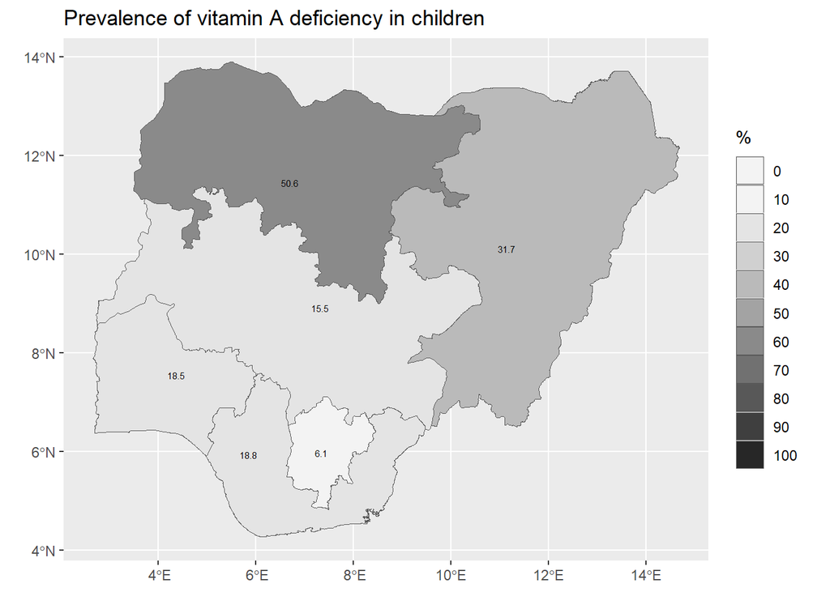

```r
ggplot(vect_gpz_geo_NFCMS) +
  geom_spatvector(aes(fill = CH_def_vit_A_pc_236)) +
  geom_spatvector_text(aes(label = CH_def_vit_A_pc_236), size = 2) +
  scale_fill_stepsn(
    n.breaks = 10,
    limits = c(0, 100),
    colours = hcl.colors(palette = "Grays", 10, rev = T),
    guide = "legend",
    na.value = "pink",
    labels = scales::comma
  ) +
  labs(title = "Prevalence of vitamin A deficiency in children", fill = " %") +
  theme(
    plot.title = element_markdown(),
    legend.title = element_markdown(),
    axis.title = element_blank()
  )
```

```r
df_NFCMS_vit_A_deficiency_CH <- as.data.frame(vect_gpz_geo_NFCMS)

df_NFCMS_vit_A_deficiency_CH_normalised <- as.data.frame(lapply(select(df_NFCMS_vit_A_deficiency_CH, CH_def_vit_A_pc_236 ), minMax))

head(df_NFCMS_vit_A_deficiency_CH_normalised)
```

CH_def_vit_A_pc_236 1 0.2112360 2 0.5752809 3 1.0000000 4 0.0000000 5 0.2853933 6 0.2786517

```r
df_NFCMS_vit_A_deficiency_CH_rescale <- bind_cols(select(df_NFCMS_vit_A_deficiency_CH, geopolitical_zone), df_NFCMS_vit_A_deficiency_CH_normalised)
```

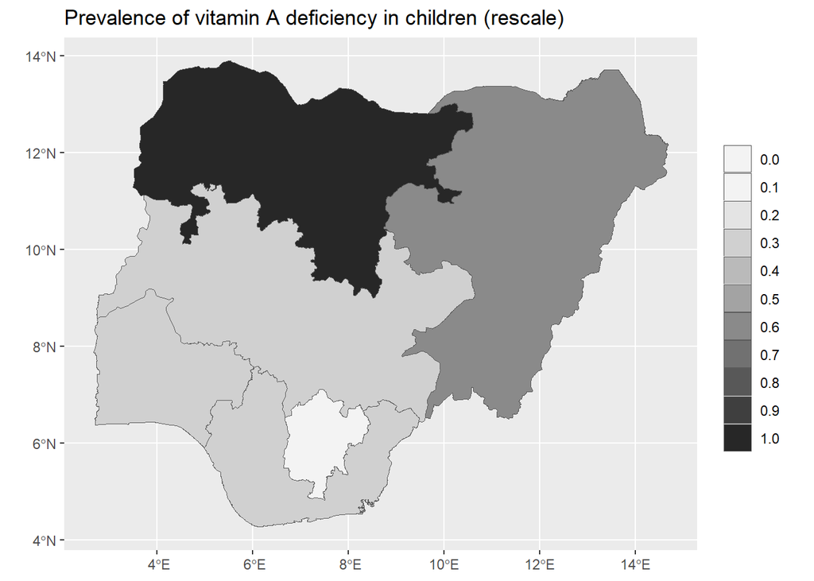

```r
vect_state_geo_NFCMS_vit_A_deficiency_CH_rescale <- dplyr::left_join(vect_gpz_geo, df_NFCMS_vit_A_deficiency_CH_rescale, by = "geopolitical_zone")

ggplot(vect_state_geo_NFCMS_vit_A_deficiency_CH_rescale) +
  geom_spatvector(aes(fill = CH_def_vit_A_pc_236)) +
  scale_fill_stepsn(
    n.breaks = 10,
    limits = c(0, 1),
    colours = hcl.colors(palette = "Grays", 10, rev = T),
    guide = "legend",
    na.value = "pink",
    labels = scales::comma
  ) +
  labs(title = "Prevalence of vitamin A deficiency in children (rescale)", fill = "") +
  theme(
    plot.title = element_markdown(),
    legend.title = element_markdown(),
    axis.title = element_blank()
  )
```

## Rescale age standardised DALYs Vitamin A Deficiency (IHME, 2023)

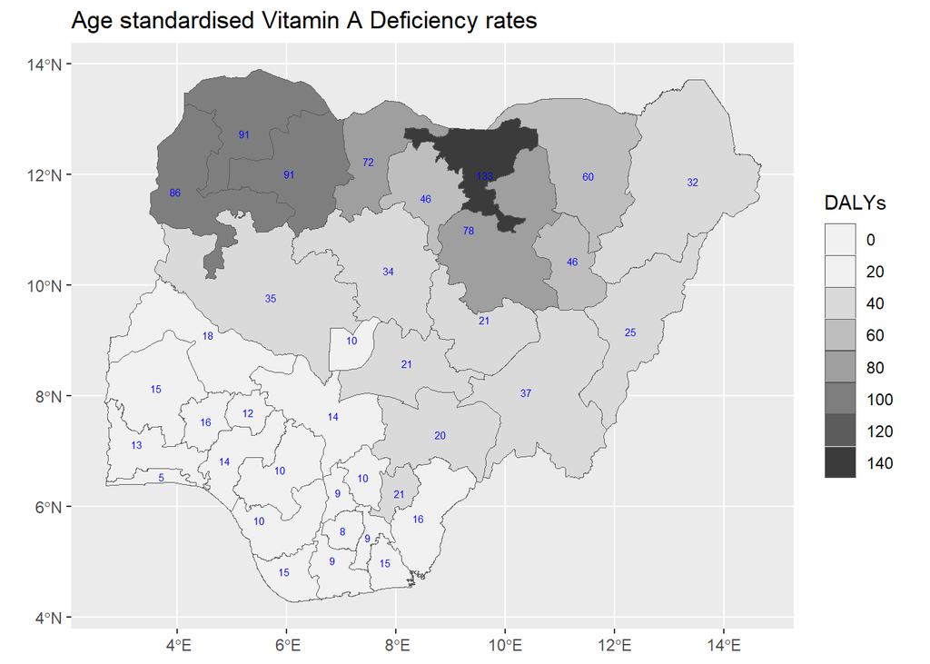

```r
ggplot(tidyterra::filter(vect_state_geo_IHME, cause_name == "Vitamin A deficiency")) +
  geom_spatvector(aes(fill = val)) +
  geom_spatvector_text(aes(label = round(val)), colour = "blue", size = 2) +
  scale_fill_stepsn(
    n.breaks = 10,
    limits = c(0, 150),
    colours = hcl.colors(palette = "Grays", 10, rev = T),
    guide = "legend",
    na.value = "pink",
    labels = scales::comma
  ) +
  labs(title = "Age standardised Vitamin A Deficiency rates", fill = "DALYs") +
  theme(
    plot.title = element_markdown(),
    legend.title = element_markdown(),
    axis.title = element_blank()
  )
```

```r
df_IHME_vit_A_DALYs <- as.data.frame(tidyterra::filter(vect_state_geo_IHME, cause_name == "Vitamin A deficiency")) |> select(adm1_ref_name, val)

df_IHME_vit_A_DALYs_normalised <- as.data.frame(lapply(select(df_IHME_vit_A_DALYs, -adm1_ref_name), minMax))
head(df_IHME_vit_A_DALYs_normalised)
```

```
     val
```

1 0.03182601 2 0.15669225 3 0.07408187 4 0.03129735 5 0.57258148 6 0.07331450

```r
df_IHME_vit_A_DALYs_rescale <- bind_cols(select(df_IHME_vit_A_DALYs, adm1_ref_name), df_IHME_vit_A_DALYs_normalised)
```

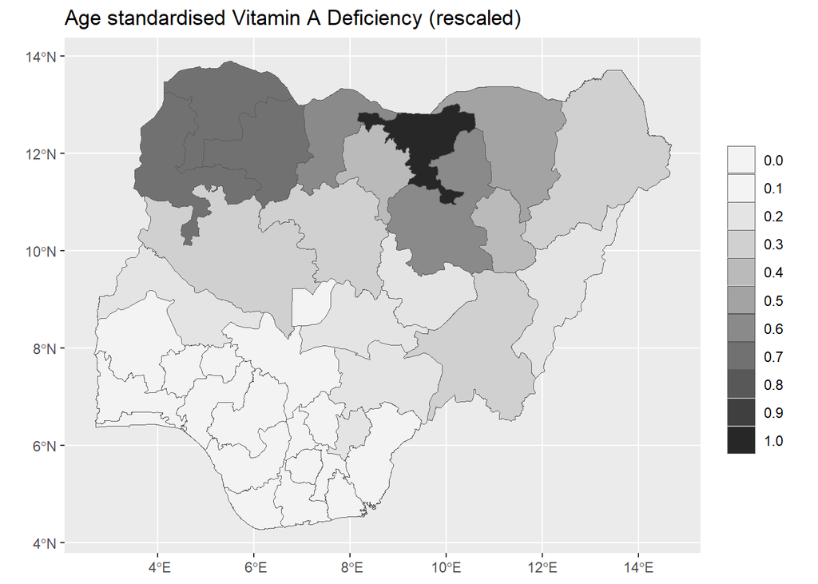

```r
vect_state_geo_IHME_vit_A_DALYs_rescale <- dplyr::left_join(vect_state_geo, df_IHME_vit_A_DALYs_rescale, by = "adm1_ref_name")

ggplot(vect_state_geo_IHME_vit_A_DALYs_rescale) +
  geom_spatvector(aes(fill = val)) +
  scale_fill_stepsn(
    n.breaks = 10,
    limits = c(0, 1),
    colours = hcl.colors(palette = "Grays", 10, rev = T),
    guide = "legend",
    na.value = "pink",
    labels = scales::comma
  ) +
  labs(title = "Age standardised Vitamin A Deficiency (rescaled)", fill = "") +
  theme(
    plot.title = element_markdown(),
    legend.title = element_markdown(),
    axis.title = element_blank()
  )
```